# Feasibility of using plant height, canopy length, canopy width, and green leaf counts for classifing palmetto plants as *Serenoa repens* or *Sabal etonia*

Mariano Viz

06/02/2021

### Summary

In this report, I fist explore the differences in plant height, canopy length, canopy width, and counts of green leaves for *Serenoa repens* or *Sabal etonia* palmetto plant species. Then, I use Binary Logistic Regression to analyze the feasibility of using these variables to accurately classify palmetto plants as *Serenoa repens* or *Sabal etonia*. Data were extracted from Abrahamson W.G. (2019).

```r
#Read in data:
palmetto_data <- read_csv(here("data", "palmetto.csv"))
```

```r
#Data wrangling:
palmetto_subset <- palmetto_data %>%
  select(species, height, length, width, green_lvs) %>% #selecting relevant columns
  mutate(species = case_when(species == "1" ~ "Serenoa repens", species == "2" ~ "Sabal etonia")) #renaming species
```

### Data Visualization

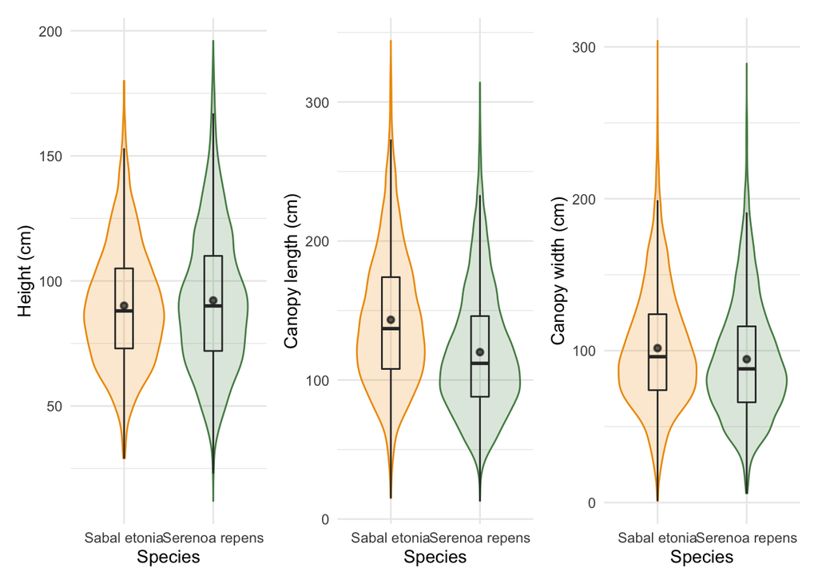

```r
##Data visualization (stored to make a compound figure):

#Data visualization (Species and Height):
sp_height_plot <- ggplot(data = palmetto_subset, aes(x = species, y = height)) +
  geom_violin(aes(color = species, fill=species), alpha = 0.2)+
  geom_boxplot(fill = NA,
               width = 0.2,
               outlier.color = NA)+
  stat_summary(fun = mean,
               alpha = 0.6,
               size = 0.3) +
  scale_fill_manual(values = c("orange2","palegreen4")) +
  scale_color_manual(values = c("orange2","palegreen4"))+
  labs(x = "Species",
       y = "Height (cm)") +
  theme_minimal() +
  theme(legend.position="none")

#Data visualization (Species and Canopy length):
sp_length_plot <- ggplot(data = palmetto_subset, aes(x = species, y = length)) +
  geom_violin(aes(color = species, fill=species), alpha = 0.2)+
  geom_boxplot(fill = NA,
               width = 0.2,
               outlier.color = NA)+
  stat_summary(fun = mean,
               alpha = 0.6,
               size = 0.3) +
  scale_fill_manual(values = c("orange2","palegreen4")) +
  scale_color_manual(values = c("orange2","palegreen4"))+
  labs(x = "Species",
       y = "Canopy length (cm)") +
  theme_minimal() +
  theme(legend.position="none")


#Data visualization (Species and Canopy width):
sp_width_plot <- ggplot(data = palmetto_subset, aes(x = species, y = width)) +
  geom_violin(aes(color = species, fill=species), alpha = 0.2)+
  geom_boxplot(fill = NA,
               width = 0.2,
               outlier.color = NA)+
  stat_summary(fun = mean,
               alpha = 0.6,
               size = 0.3) +
  scale_fill_manual(values = c("orange2","palegreen4")) +
  scale_color_manual(values = c("orange2","palegreen4"))+
  labs(x = "Species",
       y = "Canopy width (cm)") +
  theme_minimal() +
  theme(legend.position="none")


#Compound figure (patchwork):
sp_height_plot | sp_length_plot | sp_width_plot
```

**Figure 1.** Distribution of plant height (cm), canopy length (cm), and canopy width (cm) for species *Serenoa repens* and *Sabal etonia*. Box endpoints indicate the 25<sup>th</sup> and 75<sup>th</sup> percentile values. The black line and black point within the box indicate the median and mean value respectively. Data: Abrahamson, W.G. (2019).

Distribution of plant height (cm), canopy length (cm), and canopy width (cm) do not show marked differences between the two species. Greatest differences between the two species are observed with respect to the canopy length.

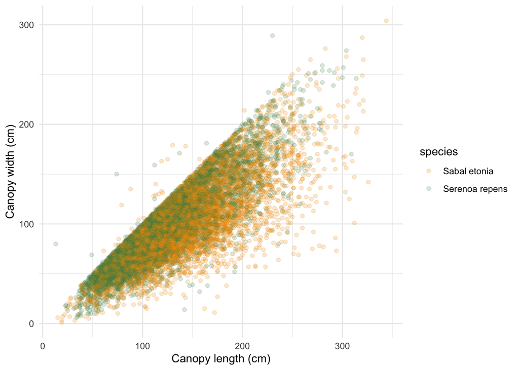

```r
#Data visualization (Canopy length and Canopy width for both species):
ggplot(data = palmetto_subset, aes(x = length, y = width)) +
  geom_point(aes(color = species), alpha = 0.2) +
  scale_color_manual(values = c("orange2","palegreen4"))+
  labs(x = "Canopy length (cm)",
       y = "Canopy width (cm)") +
  theme_minimal()
```

**Figure 2.** Relationship between canopy width (cm) and canopy length (cm) for species *Serenoa repens* and *Sabal etonia*. Green and orange points indicate individual observation for *Serenoa repens* and *Sabal etonia* respectively. Data: Abrahamson, W.G. (2019).

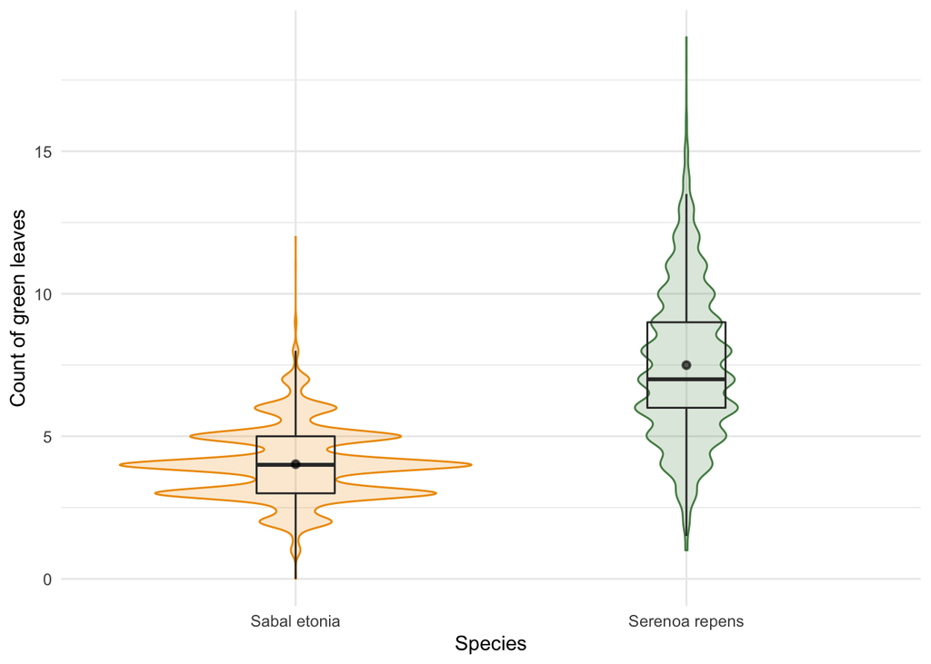

```r
#Data visualization (Species and Count of green leaves):
ggplot(data = palmetto_subset, aes(x = species, y = green_lvs)) +
  geom_violin(aes(color = species, fill=species), alpha = 0.2)+
  geom_boxplot(fill = NA,
               width = 0.2,
               outlier.color = NA)+
  stat_summary(fun = mean,
               alpha = 0.6,
               size = 0.3) +
  scale_fill_manual(values = c("orange2","palegreen4")) +
  scale_color_manual(values = c("orange2","palegreen4"))+
  labs(x = "Species",
       y = "Count of green leaves") +
  theme_minimal() +
  theme(legend.position="none")
```

**Figure 3.** Distribution of green leaves for species *Serenoa repens* and *Sabal etonia*. Box endpoints indicate the 25<sup>th</sup> and 75<sup>th</sup> percentile values. The black line and black point within the box indicate the median and mean value respectively. Data: Abrahamson, W.G. (2019).

Distribution of the green leaf counts varies markedly for the two spices where *Sabal etonia* shows lower values and less variability than *Serenoa repens*.

### Binary Logistic Regression

**Table 1.** Binary Logistic Regression model results. Data: Abrahamson, W.G. (2019).

```r
#Convert Species column to factor:
palmetto_blr <- palmetto_subset %>%
mutate(species = as.factor(species)) #convert species to factor

#Binary Logistic Regression:
palmetto_species_blr <- glm(species ~ height + length + width + green_lvs,
                            data = palmetto_blr,
                            family = "binomial")

#Observation of the outcomes:
    #palmetto_species_blr
    #summary(palmetto_species_blr)


#Finalized table with model outcomes:
palmetto_species_blr_tidy <-
  broom::tidy(palmetto_species_blr) %>%
  select(term, estimate, std.error, p.value) %>%
  mutate(p.value = case_when(p.value != "1" ~ "<2e-16")) %>%
  kable(col.names = c("Variable", "Coefficient", "Standar Error", "Significance (p.value)")) %>%
  kable_styling(bootstrap_options = "striped")

palmetto_species_blr_tidy
```

| Variable | Coefficient | Standar Error | Significance (p.value) |
| --- | --- | --- | --- |
| (Intercept) | -3.2266851 | 0.1420708 | <2e-16 |
| height | 0.0292173 | 0.0023061 | <2e-16 |
| length | -0.0458233 | 0.0018661 | <2e-16 |
| width | -0.0394434 | 0.0021000 | <2e-16 |
| green_lvs | 1.9084747 | 0.0388634 | <2e-16 |

### Model’s ability to correctly classify species (*Serenoa repens* / *Sabal etonia*)

**Table 2.** Model’s ability to correctly classified plants as *Serenoa repens* or *Sabal etonia* based on the variables plant height, canopy length, canopy width, and counts of green leaves. Data: Abrahamson, W.G. (2019).

```r
#Probability of being Serenoa repens (non-zero level):
blr_fitted <- palmetto_species_blr %>%
  broom::augment(type.predict = "response") #broom::augment to find actual probabilities



#Table about how successfully this model classify a plant as the correct species:
blr_prob <- blr_fitted %>%
  select(species, .fitted) %>%
  mutate(classification = case_when(.fitted >= "0.5" ~ "Serenoa repens",
                                    TRUE ~ "Sabal etonia")) %>%
  mutate(prediction = case_when(species == classification ~ "Correct",
                             species != classification ~ "Incorrect")) %>%
  group_by(species, prediction) %>%
  summarise(n()) %>%
  pivot_wider(names_from = prediction, values_from = "n()") %>%
  mutate(percent_correct = round(100*(Correct/(Correct+Incorrect)), digits=2)) %>%
  kable(col.names = c("Species", "Correct", "Incrorrect", "Percent correctly classified")) %>%
  kable_styling(bootstrap_options = "striped")



blr_prob
```

| Species | Correct | Incrorrect | Percent correctly classified |
| --- | --- | --- | --- |
| Sabal etonia | 5574 | 581 | 90.56 |
| Serenoa repens | 5548 | 564 | 90.77 |

Data source: Abrahamson, W.G. 2019. Survival, growth and biomass estimates of two dominant palmetto species of south-central Florida from 1981 - 2017, ongoing at 5-year intervals ver 1. Environmental Data Initiative. https://doi.org/10.6073/pasta/f2f96ec76fbbd4b9db431c79a770c4d5